# Techniki wizualizacji danych - Praca domowa nr 5

Piotr Halama

## Cel

Analiza błędów w odczycie z wykresu kołowego w porównaniu z wykresem słupkowym.

## Realizacja

Ankieta została przeprowadzona na platformie Mechanical Turk.

Kopia ankiety znajduje się tutaj.

Eksperyment został zakończony po otrzymaniu 25 odpowiedzi. Dodatkowo zostało odrzuconych 9 odpowiedzi z powodu niezrozumienia treści przez ankietowanych.

Poniższa tabela przedstawia dane użyte w eksperymencie.

| Group | Size |
| --- | --- |
| Group A | 14 |
| Group B | 23 |
| Group C | 37 |
| Group D | 5 |
| Group E | 21 |

### Wykresy użyte w eksperymencie

Wykres kołowy

Wykres słupkowy

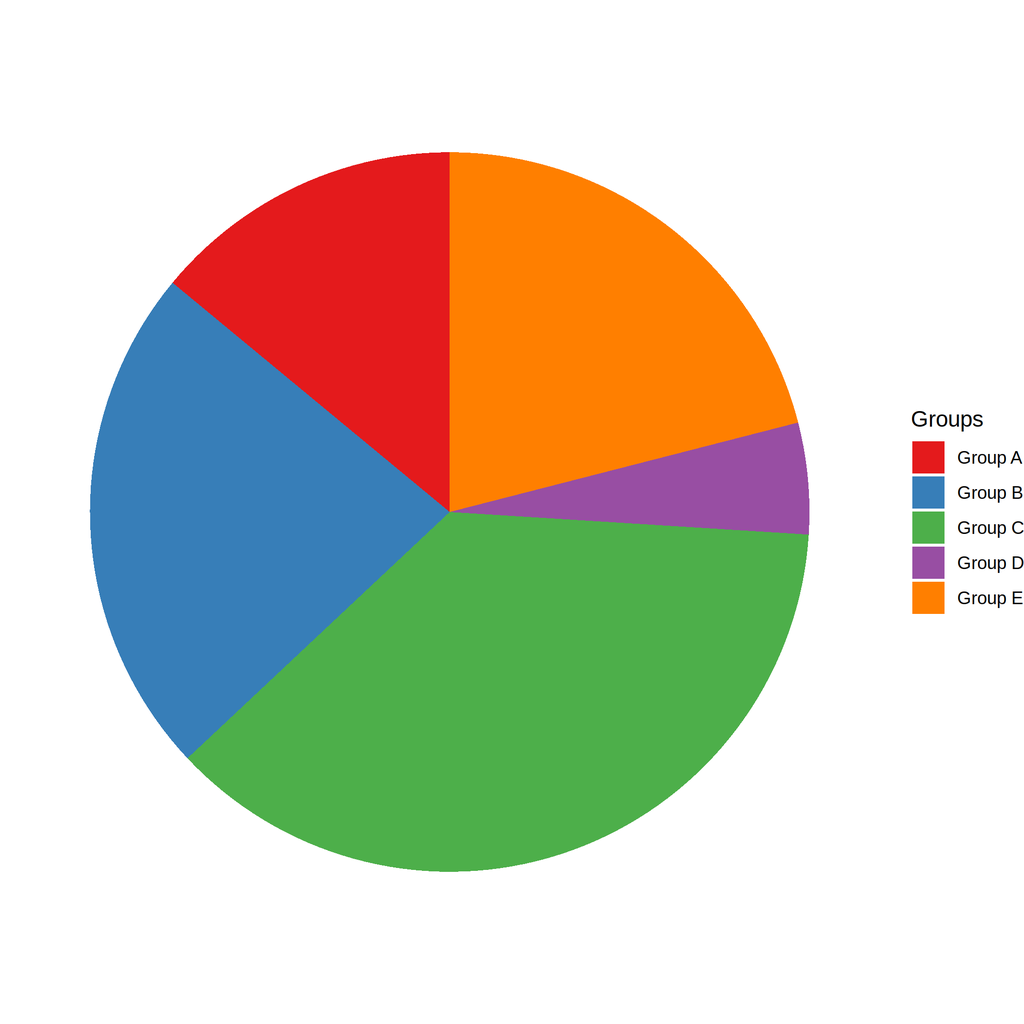

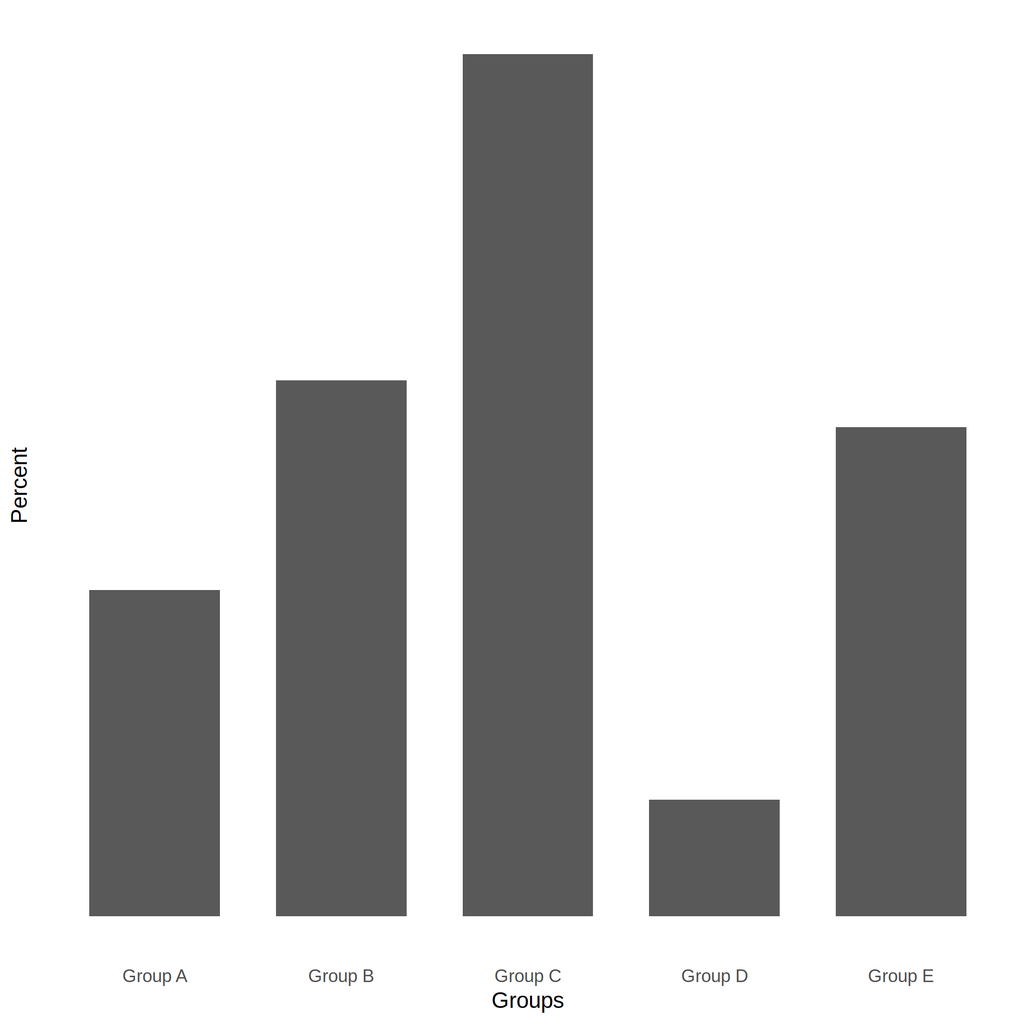

## Wyniki

### Porównanie grup

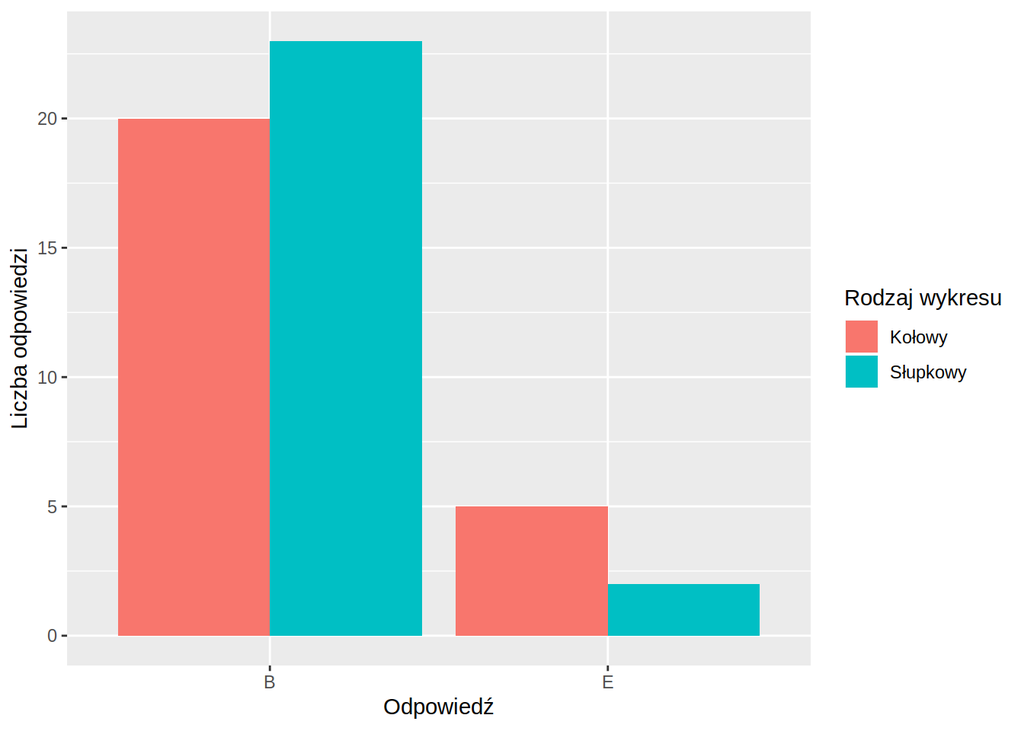

Na wykresie słupkowym większą grupę poprawnie wskazało 23 osoby z 25, podczas gdy na wykresie kołowym 20 osób.

Spośród 5 osób, które błędnie wskazały grupę na wykresie kołowym, 4 odpowiedziały poprawnie na wykresie słupkowym. Jedna osoba prawidłowo wskazała grupę na wykresie kołowym, a następnie błędnie na słupkowym.

Różnica między wartościami grup była zaledwie 2%: oczekiwałem większej różnicy między rodzajami wykresów.

### Estymacja wartości z wykresu

#### Estymacja największej grupy

Poniższa tabela przedstawia wyniki dla największej grupy.

| Wykres | Prawdziwa wartość | Średnia | Odchylenie standardowe | Maks. | Min. |
| --- | --- | --- | --- | --- | --- |
| Kołowy | 37 | 30.52 | 14.91956 | 60 | 9 |
| Słupkowy | 37 | 31.56 | 11.98986 | 50 | 15 |

Ankietowani średnio odpowiedzieli lepiej w przypadku wykresu słupkowego. Dodatkowo ich odpowiedzi były mniej rozrzucone.

##### Zależność błędu absolutnego odpowiedzi od czasu odpowiedzi

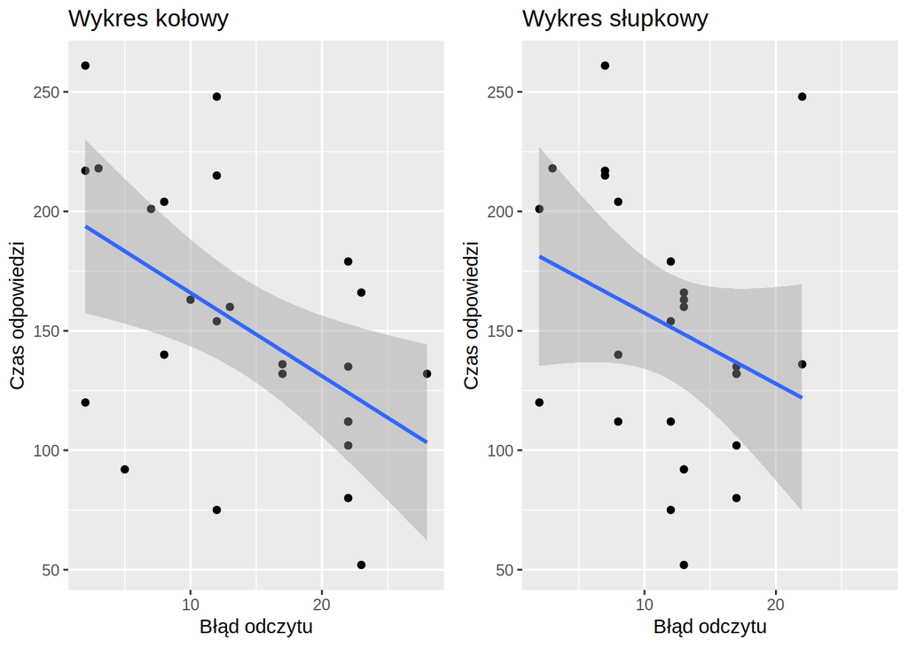

Im dłuższy czas odpowiedzi, tym bardziej poprawne były odpowiedzi ankietowanych.

##### Rozkład błędów absolutnych odpowiedzi

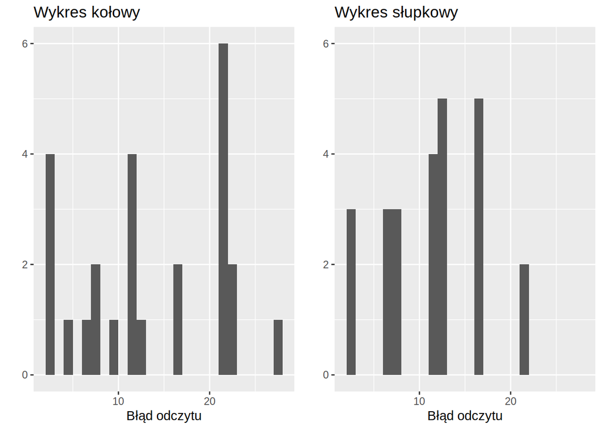

#### Estymacja średniej grupy

Poniższa tabela przedstawia wyniki dla estymacji średniej grupy.

| Wykres | Prawdziwa wartość | Średnia | Odchylenie standardowe | Maks. | Min. |
| --- | --- | --- | --- | --- | --- |
| Kołowy | 14 | 14.76 | 6.319810 | 35 | 7 |
| Słupkowy | 14 | 17.56 | 7.906116 | 45 | 8 |

W tym przypadku sytuacja się odwróciła: ankietowani średnio lepiej odczytali wartość z wykresu kołowego. Wartość średnia odpowiedzi dla wykresu kołowego jest zadziwiająco bliska prawdziwej.

##### Zależność błędu absolutnego odpowiedzi od czasu odpowiedzi

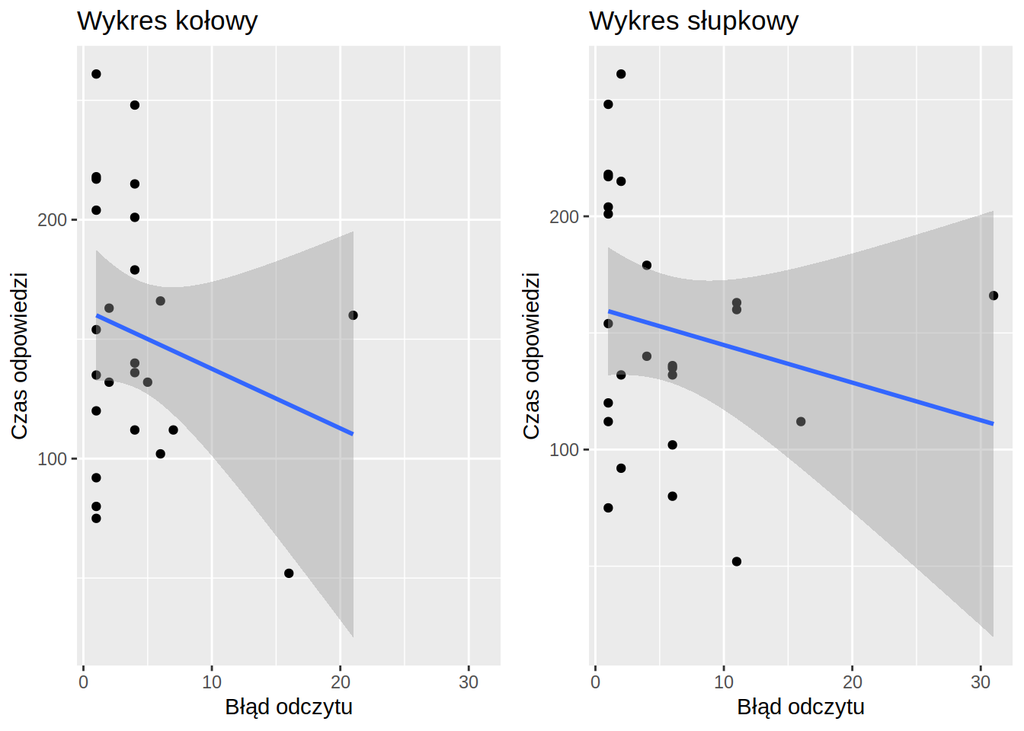

##### Rozkład błędów absolutnych odpowiedzi

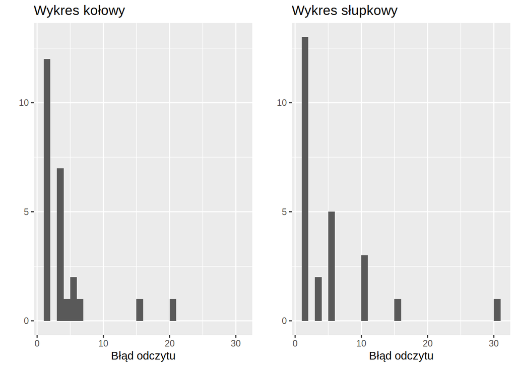

## Wnioski

Wykres słupkowy sprawdził się lepiej w 2 z 3 pytań.

Mimo to, różnice między wykresami okazały się niewielkie, a większy wpływ na poprawność odpowiedzi miał czas.

Jednakże, te wyniki należy brać z przymrużeniem oka. Próba była mała, pochodziła z populacji, która się na co dzień zajmuje annotacją danych. Nie została też postawiona prawidłowa hipoteza badawcza.